# Exercises from “Model Basics with modelr”

#### 23.2.1 Exercises

##### 1. Fit a linear model to the simulated data below, and visualise the results. Rerun a few times to generate different simulated datasets. What do you notice about the model?

```r
library(tidyverse)
sim1a <- tibble(
  x = rep(1:10, each = 3),
  y = x * 1.5 + 6 + rt(length(x), df = 2)
)
```

We compare the results for twelve simulated sets, using `facet_wrap`.

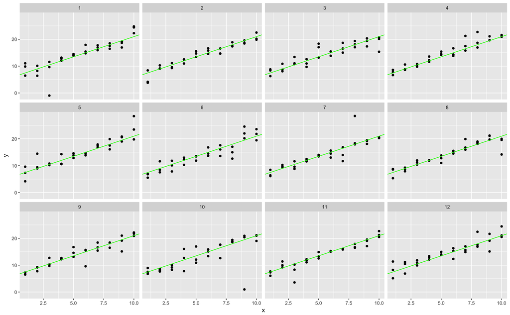

```r
#generate the data with the t distribution, which is more likely than the normal distribution
#to produce distant outliers
sim1a_generation <- function(n) {
  tibble(
    n = n,
    x = rep(1:10, each = 3),
    y = x * 1.5 + 6 + rt(length(x), df = 2)
  )
}
facet_data <- map_df(1:12, sim1a_generation)
ggplot(facet_data) + geom_point(aes(x=x, y=y)) +
  geom_abline(aes(intercept = lm(y~x, facet_data)[[1]][[1]],
                  slope = lm(y~x, facet_data)[[1]][[2]]),
              color = "green") +
  facet_wrap(~ n, ncol = 4)
```

I expected to see more affect on the lines from the outliers in these plots.

##### 2. Use optim() to fit a linear model to the simulated data above, using mean-absolute distance rather than root-mean-squared distance, and compare the result to the linear model.

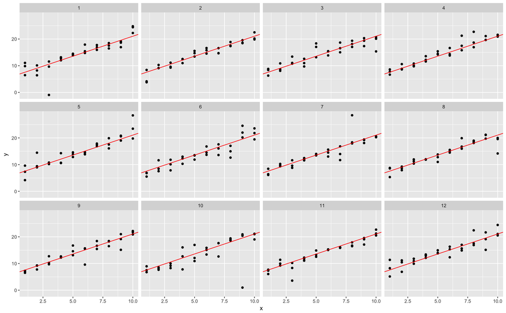

```r
#use a linear model to predict the y values, given the x values
model1 <- function(a, data) {
  a[1] + data$x * a[2]
}
#find the average of the absolute deviation, from the model, of the y values in the data
measure_distance <- function(mod, data) {
  diff <- data$y - model1(mod, data)
  mean(abs(diff))
}
#use a facet_wrap, as with the root-mean-squared fitting
ggplot(facet_data) + geom_point(aes(x = x, y = y)) +
  geom_abline(aes(intercept = optim(c(0, 0), measure_distance, data = facet_data)$par[1],
                  slope = optim(c(0, 0), measure_distance, data = facet_data)$par[2]),
              color = "red") +
  facet_wrap(~ n, ncol = 4)
```

#### 23.3.3 Exercises

##### 1. Repeat the process of model fitting, grid generation, predictions, and visualisation on sim1 using loess() instead of lm(). How does the result compare to geom_smooth()?

We compare for two values of the parameter `span`, which specifies the neighborhood widths (lower numbers indicate closer fitting to nearby values in the data). First of for span = 0.5.

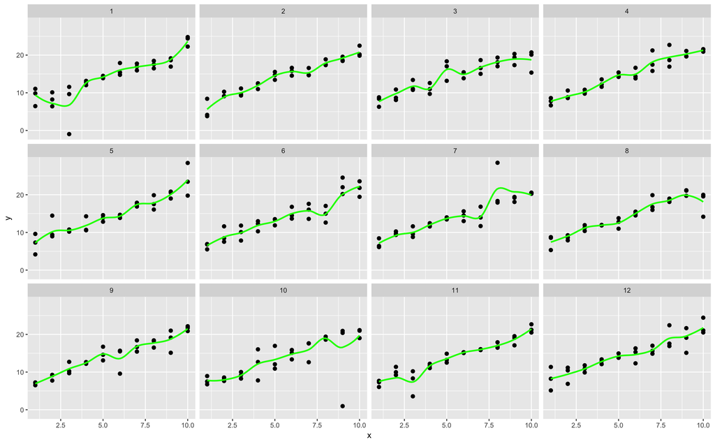

```r
ggplot(facet_data, aes(x=x, y=y)) + geom_point(size = 2) +
  geom_smooth(method = "loess", color = "green",
              se = FALSE, span = 0.5) +
  facet_wrap(~ n, ncol = 4)
```

These loess curves are noticeably more susceptible to influence from outliers, and perhaps overfitting.

Now use the loess method with span = 0.75.

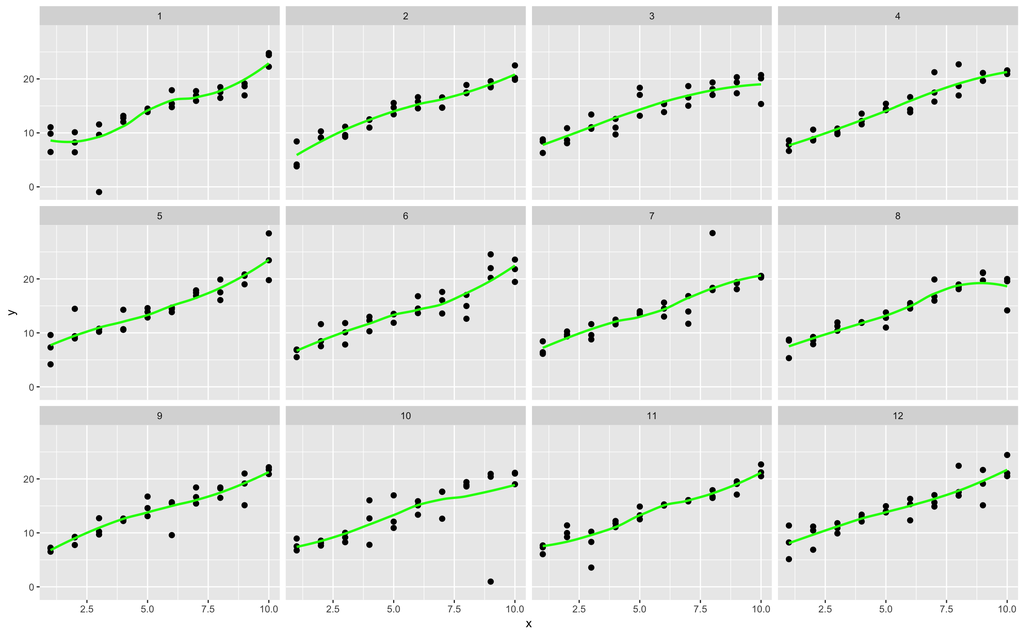

```r
ggplot(facet_data, aes(x=x, y=y)) + geom_point(size = 2) +
  geom_smooth(method = "loess", color = "green",
              se = FALSE, span = .75) +
  facet_wrap(~ n, ncol = 4)
```

As expected, the wider span of the neighborhoods makes the model-fit somewhat less susceptible to the outliers, and perhaps overfitting.

##### 2. `add_predictions()` is paired with `gather_predictions()` and `spread_predictions()`. How do these three functions differ?

`add_predictions` places a new column in the data with a single prediction. `spread_predictions` adds more than one prediction, each in its own column. `gather_predictions` stacks the predictions (more than one) in a single column, in the manner of the `gather()` function and “tidy” data.

##### 3. What does geom_ref_line() do? What package does it come from? Why is displaying a reference line in plots showing residuals useful and important?

`geom_ref_line()`, which is part of the modelr package, adds a line to a plot, which may help in the examination of residuals.

###### 4.

Why might you want to look at a frequency polygon of absolute residuals? What are the pros and cons compared to looking at the raw residuals?

Pro: makes the absolute residuals more visible, with twice the contrast

Con: may hide bias in the original model if, for example, the positive residuals tend to be greater than the negative residuals

#### 23.4.5 Exercises

##### 1. What happens if you repeat the analysis of sim2 using a model without an intercept. What happens to the model equation? What happens to the predictions?

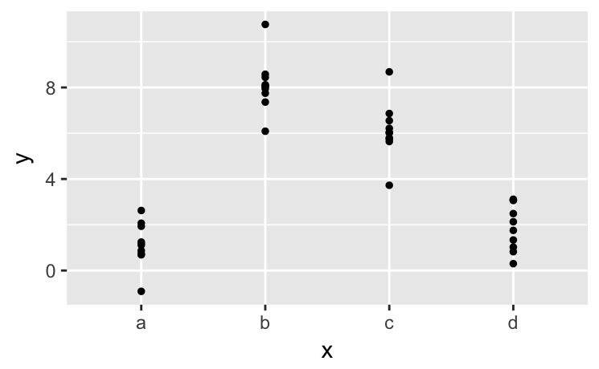

```r
ggplot(sim2) + geom_point(aes(x, y), size = 1)
```

```r
mod2 <- lm(y ~ x - 1, data = sim2)
grid <- sim2 %>%
  data_grid(x) %>%
  add_predictions(mod2)
grid
```

| x | pred |
| --- | --- |
| a | 1.152166 |
| b | 8.116039 |
| c | 6.127191 |
| d | 1.910981 |

This result is the same as what we would get if using y ~ x instead of y ~ x - 1.

##### 2. Use model_matrix() to explore the equations generated for the models I fit to sim3 and sim4. Why is * a good shorthand for interaction?

First have a look at sim3:

```r
head(sim3)
```

| x1 | x2 | rep | y | sd |
| --- | --- | --- | --- | --- |
| 1 | a | 1 | -0.5707363 | 2 |
| 1 | a | 2 | 1.1841503 | 2 |
| 1 | a | 3 | 2.2373204 | 2 |
| 1 | b | 1 | 7.4366963 | 2 |
| 1 | b | 2 | 8.5182934 | 2 |
| 1 | b | 3 | 7.7239098 | 2 |

The result of using `+` in the model function:

```r
model_matrix(sim3, y ~ x1 + x2)
```

| (Intercept) | x1 | x2b | x2c | x2d |
| --- | --- | --- | --- | --- |
| 1 | 1 | 0 | 0 | 0 |
| 1 | 1 | 0 | 0 | 0 |
| 1 | 1 | 0 | 0 | 0 |
| 1 | 1 | 1 | 0 | 0 |
| 1 | 1 | 1 | 0 | 0 |
| 1 | 1 | 1 | 0 | 0 |
| 1 | 1 | 0 | 1 | 0 |
| 1 | 1 | 0 | 1 | 0 |
| 1 | 1 | 0 | 1 | 0 |
| 1 | 1 | 0 | 0 | 1 |

[output cut: 110 more lines]

Compare the above to the result of using `*`:

```r
model_matrix(sim3, y ~ x1 * x2)
```

| (Intercept) | x1 | x2b | x2c | x2d | x1:x2b | x1:x2c | x1:x2d |
| --- | --- | --- | --- | --- | --- | --- | --- |
| 1 | 1 | 0 | 0 | 0 | 0 | 0 | 0 |
| 1 | 1 | 0 | 0 | 0 | 0 | 0 | 0 |
| 1 | 1 | 0 | 0 | 0 | 0 | 0 | 0 |
| 1 | 1 | 1 | 0 | 0 | 1 | 0 | 0 |
| 1 | 1 | 1 | 0 | 0 | 1 | 0 | 0 |
| 1 | 1 | 1 | 0 | 0 | 1 | 0 | 0 |
| 1 | 1 | 0 | 1 | 0 | 0 | 1 | 0 |
| 1 | 1 | 0 | 1 | 0 | 0 | 1 | 0 |
| 1 | 1 | 0 | 1 | 0 | 0 | 1 | 0 |
| 1 | 1 | 0 | 0 | 1 | 0 | 0 | 1 |

[output cut: 110 more lines]

Flipping through this dataframe, we can see how `*` allows us to search for interaction, in a way that `+` does not.

Next have a look at sim4:

```r
sim4
```

| model | model | x1 | x2 | rep | y | resid |
| --- | --- | --- | --- | --- | --- | --- |
| mod1 | mod1 | -1.0000000 | -1.0000000 | 1 | 4.2476776865 | 3.251368307 |
| mod1 | mod1 | -1.0000000 | -1.0000000 | 2 | 1.2059970139 | 0.209687634 |
| mod1 | mod1 | -1.0000000 | -1.0000000 | 3 | 0.3534776989 | -0.642831681 |
| mod1 | mod1 | -1.0000000 | -0.7777778 | 1 | -0.0466581383 | -0.424630738 |
| mod1 | mod1 | -1.0000000 | -0.7777778 | 2 | 4.6386898663 | 4.260717266 |
| mod1 | mod1 | -1.0000000 | -0.7777778 | 3 | 1.3770954039 | 0.999122804 |
| mod1 | mod1 | -1.0000000 | -0.5555556 | 1 | 0.9752208792 | 1.215585059 |
| mod1 | mod1 | -1.0000000 | -0.5555556 | 2 | 2.4996375290 | 2.740001709 |
| mod1 | mod1 | -1.0000000 | -0.5555556 | 3 | 2.7047483728 | 2.945112553 |
| mod1 | mod1 | -1.0000000 | -0.3333333 | 1 | 0.5575152233 | 1.416216183 |

[output cut: 990 more lines]

```r
model_matrix(sim4, y ~ x1 + x2)
```

| (Intercept) | x1 | x2 |
| --- | --- | --- |
| 1 | -1.0000000 | -1.0000000 |
| 1 | -1.0000000 | -1.0000000 |
| 1 | -1.0000000 | -1.0000000 |
| 1 | -1.0000000 | -0.7777778 |
| 1 | -1.0000000 | -0.7777778 |
| 1 | -1.0000000 | -0.7777778 |
| 1 | -1.0000000 | -0.5555556 |
| 1 | -1.0000000 | -0.5555556 |
| 1 | -1.0000000 | -0.5555556 |
| 1 | -1.0000000 | -0.3333333 |

[output cut: 990 more lines]

Compare this to the result of the use of `*` in the sim4 model formula:

```r
model_matrix(sim4, y ~ x1 * x2)
```

| (Intercept) | x1 | x2 | x1:x2 |
| --- | --- | --- | --- |
| 1 | -1.0000000 | -1.0000000 | 1.00000000 |
| 1 | -1.0000000 | -1.0000000 | 1.00000000 |
| 1 | -1.0000000 | -1.0000000 | 1.00000000 |
| 1 | -1.0000000 | -0.7777778 | 0.77777778 |
| 1 | -1.0000000 | -0.7777778 | 0.77777778 |
| 1 | -1.0000000 | -0.7777778 | 0.77777778 |
| 1 | -1.0000000 | -0.5555556 | 0.55555556 |
| 1 | -1.0000000 | -0.5555556 | 0.55555556 |
| 1 | -1.0000000 | -0.5555556 | 0.55555556 |
| 1 | -1.0000000 | -0.3333333 | 0.33333333 |

[output cut: 990 more lines]

We see, in this case in which none of the variables is a factor or character variable, that the interaction term is simply the product of the two variables. And of course, for both sim3 and sim4, using * allows us to consider the interaction between the two variables.

##### 3. Using the basic principles, convert the formulas in the following two models into functions. (Hint: start by converting the categorical variable into 0-1 variables.)

```r
mod1 <- lm(y ~ x1 + x2, data = sim3)
mod2 <- lm(y ~ x1 * x2, data = sim3)
```

For the more-complicated of these two cases, consider again the application of `model_matrix()`:

```r
model_matrix(y ~ x1 * x2, data = sim3)
```

| (Intercept) | x1 | x2b | x2c | x2d | x1:x2b | x1:x2c | x1:x2d |
| --- | --- | --- | --- | --- | --- | --- | --- |
| 1 | 1 | 0 | 0 | 0 | 0 | 0 | 0 |
| 1 | 1 | 0 | 0 | 0 | 0 | 0 | 0 |
| 1 | 1 | 0 | 0 | 0 | 0 | 0 | 0 |
| 1 | 1 | 1 | 0 | 0 | 1 | 0 | 0 |
| 1 | 1 | 1 | 0 | 0 | 1 | 0 | 0 |
| 1 | 1 | 1 | 0 | 0 | 1 | 0 | 0 |
| 1 | 1 | 0 | 1 | 0 | 0 | 1 | 0 |
| 1 | 1 | 0 | 1 | 0 | 0 | 1 | 0 |
| 1 | 1 | 0 | 1 | 0 | 0 | 1 | 0 |
| 1 | 1 | 0 | 0 | 1 | 0 | 0 | 1 |

[output cut: 110 more lines]

In terms of the variables in the headings in the above, the formula would be:

`y = a_0 + a_1*x1 + a_22*x2b + a_23*x2c + a_24*x2d + a_122*x1*x2b + a_123*x1*x2c + a_124*x1*x2d`

Note that the translation of ‘x2 = a’ is ‘(x2b, x2c, x2d) = (0, 0, 0)’. Given this, perhaps we may think of the intercept term, a_0, as capturing the some of the effect of x2 = a, if this is the case?

##### 4. For sim4, which of mod1 and mod2 is better? I think mod2 does a slightly better job at removing patterns, but it’s pretty subtle. Can you come up with a plot to support my claim?

Having a quick look at sim4:

```r
head(sim4)
```

| model | model | x1 | x2 | rep | y | resid |
| --- | --- | --- | --- | --- | --- | --- |
| mod1 | mod1 | -1 | -1.0000000 | 1 | 4.24767769 | 3.2513683 |
| mod1 | mod1 | -1 | -1.0000000 | 2 | 1.20599701 | 0.2096876 |
| mod1 | mod1 | -1 | -1.0000000 | 3 | 0.35347770 | -0.6428317 |
| mod1 | mod1 | -1 | -0.7777778 | 1 | -0.04665814 | -0.4246307 |
| mod1 | mod1 | -1 | -0.7777778 | 2 | 4.63868987 | 4.2607173 |
| mod1 | mod1 | -1 | -0.7777778 | 3 | 1.37709540 | 0.9991228 |

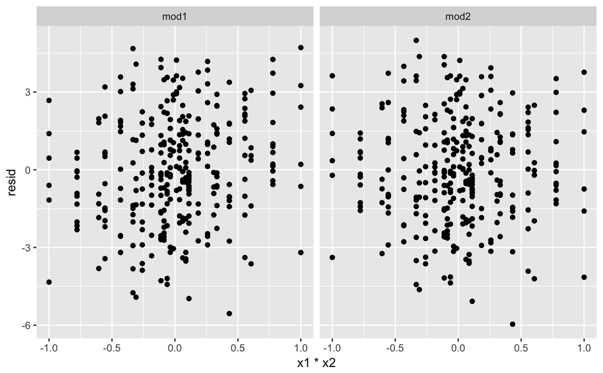

```r
mod1 <- lm(y ~ x1 + x2, data = sim4)
mod2 <- lm(y ~ x1 * x2, data = sim4)
sim4 <- sim4 %>%
  gather_residuals(mod1, mod2)
ggplot(sim4) + geom_point(aes(x = x1*x2, y = resid)) +
  facet_wrap(~ model)
```

The residuals for `mod1` (with `y ~ x1 + x2`) show a minor but noticeable relationship with x1 * x2: as x1 * x2 increases, the residuals tend to be somewhat greater. As one would expect, `mod2`, which uses (`y ~ x1 * x2`), removes this pattern in the residuals.